# Machine Learning Project

Sunday, October 26, 2014

### Machine Learning Project

Using devices such as Jawbone Up, Nike FuelBand, and Fitbit it is now possible to collect a large amount of data about personal activity relatively inexpensively. These type of devices are part of the quantified self movement – a group of enthusiasts who take measurements about themselves regularly to improve their health, to find patterns in their behavior, or because they are tech geeks. One thing that people regularly do is quantify how much of a particular activity they do, but they rarely quantify how well they do it. In this project, your goal will be to use data from accelerometers on the belt, forearm, arm, and dumbell of 6 participants. They were asked to perform barbell lifts correctly and incorrectly in 5 different ways. More information is available from the website here: http://groupware.les.inf.puc-rio.br/har (see the section on the Weight Lifting Exercise Dataset).

## Data

The training data for this project are available here:

https://d396qusza40orc.cloudfront.net/predmachlearn/pml-training.csv

The test data are available here:

https://d396qusza40orc.cloudfront.net/predmachlearn/pml-testing.csv

The data for this project come from this source: http://groupware.les.inf.puc-rio.br/har. If you use the document you create for this class for any purpose please cite them as they have been very generous in allowing their data to be used for this kind of assignment.

The first step was to clean the CSV data files of empty columns and save the new files with 53 column.

```r
dim(PML.TRAINING.REDUCE)
```

```
## [1] 19622    53
```

```r
dim(PML.TESTING.REDUCED_NO.NAME)
```

```
## [1] 20 53
```

```r
names(PML.TESTING.REDUCED_NO.NAME)
```

```
##  [1] "roll_belt"            "pitch_belt"           "yaw_belt"
##  [4] "total_accel_belt"     "gyros_belt_x"         "gyros_belt_y"
##  [7] "gyros_belt_z"         "accel_belt_x"         "accel_belt_y"
## [10] "accel_belt_z"         "magnet_belt_x"        "magnet_belt_y"
## [13] "magnet_belt_z"        "roll_arm"             "pitch_arm"
## [16] "yaw_arm"              "total_accel_arm"      "gyros_arm_x"
## [19] "gyros_arm_y"          "gyros_arm_z"          "accel_arm_x"
## [22] "accel_arm_y"          "accel_arm_z"          "magnet_arm_x"
## [25] "magnet_arm_y"         "magnet_arm_z"         "roll_dumbbell"
## [28] "pitch_dumbbell"       "yaw_dumbbell"         "total_accel_dumbbell"
## [31] "gyros_dumbbell_x"     "gyros_dumbbell_y"     "gyros_dumbbell_z"
## [34] "accel_dumbbell_x"     "accel_dumbbell_y"     "accel_dumbbell_z"
## [37] "magnet_dumbbell_x"    "magnet_dumbbell_y"    "magnet_dumbbell_z"
## [40] "roll_forearm"         "pitch_forearm"        "yaw_forearm"
## [43] "total_accel_forearm"  "gyros_forearm_x"      "gyros_forearm_y"
## [46] "gyros_forearm_z"      "accel_forearm_x"      "accel_forearm_y"
## [49] "accel_forearm_z"      "magnet_forearm_x"     "magnet_forearm_y"
## [52] "magnet_forearm_z"     "problem_id"
```

## Cross Validation using Random Forest library

```r
library(AppliedPredictiveModeling)
library(randomForest)
library(caret)
```

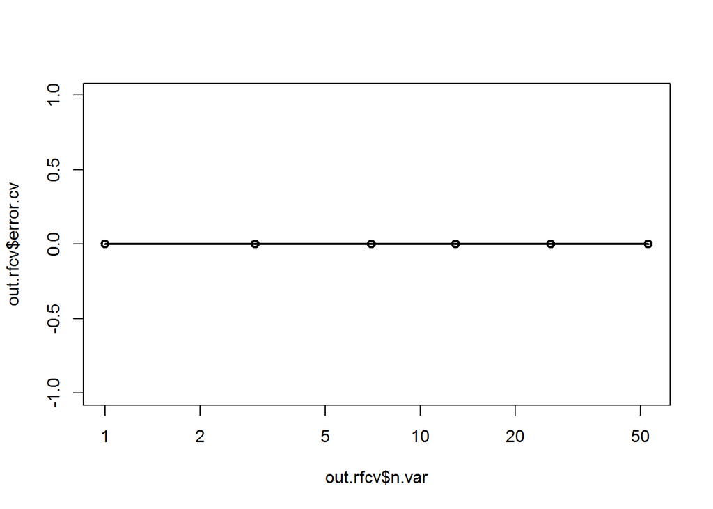

```r
set.seed(2014)

out.rfcv <- rfcv(PML.TRAINING.REDUCE, PML.TRAINING.REDUCE$classe, cv.fold=5, scale="log", step=0.5)
plot(out.rfcv$n.var, out.rfcv$error.cv, log="x", type="o", lwd=2)
```

Using the Random Forest Cross-Validation for feature selection. The error.cv seems to be constant over the log the number of variables.

## Modeling with Random Forest

```r
rfTree <- randomForest(PML.TRAINING.REDUCE$classe~.,  data = PML.TRAINING.REDUCE)

rfTree
```

```
##
## Call:
##  randomForest(formula = PML.TRAINING.REDUCE$classe ~ ., data = PML.TRAINING.REDUCE)
##                Type of random forest: classification
##                      Number of trees: 500
## No. of variables tried at each split: 7
##
##         OOB estimate of  error rate: 0.33%
## Confusion matrix:
##      A    B    C    D    E  class.error
## A 5577    2    0    0    1 0.0005376344
## B   11 3783    3    0    0 0.0036871214
## C    0   13 3408    1    0 0.0040911748
## D    0    0   26 3188    2 0.0087064677
## E    0    0    1    4 3602 0.0013861935
```

## Prediction with Random Forest

```r
predict(rfTree,PML.TESTING.REDUCED_NO.NAME)
```

```
##  1  2  3  4  5  6  7  8  9 10 11 12 13 14 15 16 17 18 19 20
##  B  A  B  A  A  E  D  B  A  A  B  C  B  A  E  E  A  B  B  B
## Levels: A B C D E
```

The predictions yielded 100% agreement after being graded by the Automatic Grader.

## Importance of Random Forest

```r
rfTree$importance
```

```
##                      MeanDecreaseGini
## roll_belt                  1297.73032
## pitch_belt                  708.45043
## yaw_belt                    913.34811
## total_accel_belt            208.44382
## gyros_belt_x                 88.75992
## gyros_belt_y                108.33982
## gyros_belt_z                292.39307
## accel_belt_x                114.04361
## accel_belt_y                117.88627
## accel_belt_z                393.99207
## magnet_belt_x               251.85192
## magnet_belt_y               399.48932
## magnet_belt_z               396.97443
## roll_arm                    320.95853
## pitch_arm                   178.34073
## yaw_arm                     241.54714
## total_accel_arm             100.93793
## gyros_arm_x                 130.02062
## gyros_arm_y                 139.61520
## gyros_arm_z                  54.23289
## accel_arm_x                 249.02158
## accel_arm_y                 155.00602
## accel_arm_z                 128.39548
## magnet_arm_x                251.16358
## magnet_arm_y                219.76042
## magnet_arm_z                177.52069
## roll_dumbbell               405.99806
## pitch_dumbbell              172.61447
## yaw_dumbbell                246.44973
## total_accel_dumbbell        266.92643
## gyros_dumbbell_x            126.78970
## gyros_dumbbell_y            243.87053
## gyros_dumbbell_z             80.01677
## accel_dumbbell_x            248.50794
## accel_dumbbell_y            418.58651
## accel_dumbbell_z            322.06433
## magnet_dumbbell_x           496.01853
## magnet_dumbbell_y           678.54004
## magnet_dumbbell_z           765.99647
## roll_forearm                624.79021
## pitch_forearm               780.91867
## yaw_forearm                 175.89949
## total_accel_forearm         107.68562
## gyros_forearm_x              71.91173
## gyros_forearm_y             121.77733
## gyros_forearm_z              78.64684
## accel_forearm_x             318.95386
## accel_forearm_y             138.55488
## accel_forearm_z             237.30818
## magnet_forearm_x            225.94421
## magnet_forearm_y            226.10727
## magnet_forearm_z            292.55912
```

The roll, pitch and yaw for the belt seem to have high values.